```python
!pip install sdv --quiet
!pip install ctgan --quiet
!pip install pyspark==3.3.2
!pip install boto3
!pip install scikit-learn
!pip install lightgbm
!pip install xgboost
!pip install matplotlib plotly seaborn pandas
```

```python
import os
import pandas as pd
import numpy as np
from pyspark.sql import SparkSession
from sklearn.pipeline import Pipeline
from sklearn.model_selection import train_test_split, GridSearchCV
from sklearn.preprocessing import StandardScaler, OneHotEncoder
from sklearn.compose import ColumnTransformer
from sklearn.ensemble import RandomForestClassifier
import lightgbm as lgb
import matplotlib.pyplot as plt
import plotly.express as px
from ctgan import CTGAN
from IPython.display import Image, display
import warnings
warnings.filterwarnings('ignore')
```

# 🚀 **Fraud Detection Analysis**

**Author:** Aryan Kaushik

- https://github.com/aryankaushik89

# 📚 **Table of Contents**

##### 1. Project Overview

##### 2. Feature Engineering: Translating Domain Knowledge into Predictive Power

```
- [Engineering Fraud-Focused Features and Cleaning Data](#engineering-fraud-focused-features-and-cleaning-data)
```

##### 3. Exploratory Data Analysis (EDA)

```
- [Loading Data and Previewing Structure]
- [Visualizing Fraud Class Imbalance]
- [Examining Numeric Feature Distributions by Fraud Status]
- [Exploring Risk Flags, Device, and Geo Patterns]
- [Investigating Correlations Among Features]
```

##### 4. Hyperparameter Tuning and Model Training

```
- [Hyperparameter Tuning with Grid Search]
- [Model Training and Evaluation with Multiple Metrics]
```

##### 5. Model Explainability and Comparing Fraud Types

```
- [Using SHAP Values to Interpret Model Predictions]
- [Comparing First-Party and Third-Party Fraud Patterns]
```

##### 6. Final Summary and Future Enhancements

# 📊 **1. Project Overview**

This notebook demonstrates an end-to-end approach to financial fraud detection using a combination of advanced feature engineering, machine learning, and synthetic data generation. The workflow is built for transparency and reproducibility: every step, from data sourcing to model interpretation, is included as code and can be rerun from scratch. All analysis is designed to reflect both real-world fraud data challenges and the expectations of modern data science teams.

### Data Sources

The foundational data for this project comes from the [PaySim Synthetic Mobile Money Transactions Dataset](https://www.kaggle.com/datasets/ealaxi/paysim1?resource=download), which mimics one month of real-world mobile money transactions as found in emerging financial markets. PaySim’s logs include over 6 million records, with a variety of transaction types, customer behaviors, and injected fraudulent activity. The use of such realistic, privacy-safe data makes it ideal for developing and benchmarking fraud analytics workflows.

### Augmenting the Data with GANs

In addition to the original Kaggle data, this project demonstrates synthetic data generation using Generative Adversarial Networks (GANs). To further enrich the dataset, I generated additional synthetic data using a GANs, specifically CTGAN. GANs are powerful machine learning models that can learn the underlying distribution of a dataset and generate new, highly realistic records.

They are a family of deep learning models that can learn the statistical properties of a real dataset and create entirely new, artificial records that are nearly indistinguishable from real data. This technique is valuable for fraud detection projects as it:

- GANs allow us to create much larger and more varied datasets for robust ML experimentation, especially useful in rare-event scenarios like fraud.
- We can inject or simulate new types of risk patterns and attributes, such as device, geo, behavioral, and flag-based features, as is common in production fraud systems.
- Helps reduce class imbalance.

### Final Dataset

In this notebook, GANs are used (via the CTGAN implementation) to create an augmented, feature-rich synthetic dataset, `synthetic_fraud_200k.csv`, containing 200,000 synthetic transaction records. The process adds additional attributes such as device type, location, VPN usage, and risk flags, which are common in real-world anti-fraud systems. This demonstrates not only core modeling skills, but also the ability to generate realistic testbeds for algorithm development—a key asset in environments where data access is sensitive or limited.

### Data Ingestion and Synthetic Data Generation

- Ingesting the original PaySim CSV (after download from Kaggle)
- Creating engineered features
- Training a GAN (CTGAN) on a stratified sample
- Generating and saving the synthetic dataset for modeling

```python
# from google.colab import drive

# drive.mount('/content/drive')
```

```python
# --- Step 1: Ingesting original PaySim data from Kaggle ---
csv_path = '/Users/aryankaushik/Downloads/fraud_project_files/paysim_creditcard_data.csv'

df_paysim = pd.read_csv(csv_path)
print("Loaded creditcard.csv with shape:", df_paysim.shape)
df_paysim.head()
```

```
Loaded creditcard.csv with shape: (6362620, 11)
```

|  | step | type | amount | nameOrig | oldbalanceOrg | newbalanceOrig | nameDest | oldbalanceDest | newbalanceDest | isFraud | isFlaggedFraud |
| --- | --- | --- | --- | --- | --- | --- | --- | --- | --- | --- | --- |
| 0 | 1 | PAYMENT | 9839.64 | C1231006815 | 170136.0 | 160296.36 | M1979787155 | 0.0 | 0.0 | 0 | 0 |
| 1 | 1 | PAYMENT | 1864.28 | C1666544295 | 21249.0 | 19384.72 | M2044282225 | 0.0 | 0.0 | 0 | 0 |
| 2 | 1 | TRANSFER | 181.00 | C1305486145 | 181.0 | 0.00 | C553264065 | 0.0 | 0.0 | 1 | 0 |
| 3 | 1 | CASH_OUT | 181.00 | C840083671 | 181.0 | 0.00 | C38997010 | 21182.0 | 0.0 | 1 | 0 |
| 4 | 1 | PAYMENT | 11668.14 | C2048537720 | 41554.0 | 29885.86 | M1230701703 | 0.0 | 0.0 | 0 | 0 |

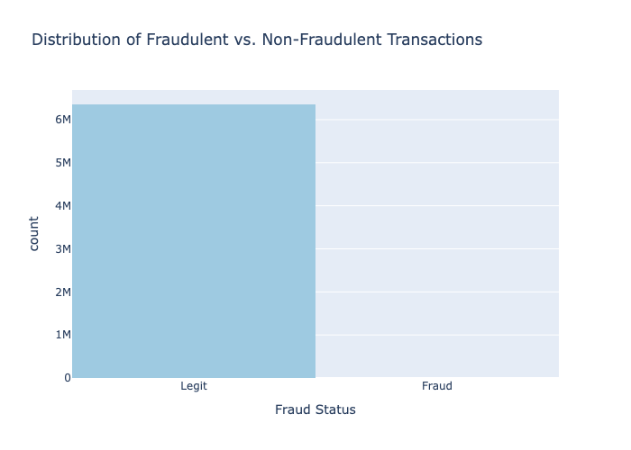

```
Plot 1: Fraud vs. Non-Fraud
```

```python
import plotly.express as px

PASTEL_BLUE = "#9ecae1"
PASTEL_PINK = "#fbb4ae"

#--- Plot the class balance: fraud vs. legitimate
fig = px.histogram(
    df_paysim, x="isFraud",
    color="isFraud",
    color_discrete_sequence=[PASTEL_BLUE, PASTEL_PINK],
    title="Distribution of Fraudulent vs. Non-Fraudulent Transactions",
    labels={"isFraud": "Fraud Status"},
    width=600, height=400
)
fig.update_xaxes(tickvals=[0,1], ticktext=["Legit", "Fraud"])
fig.update_layout(showlegend=False)
# fig.show()
fig.write_image("p1.png")
display(Image(filename="p1.png"))
print("Plot 1: Fraud vs. Non-Fraud")
```

Insight:

```python
# --- Step 2: Stratified downsampling for GAN training ---
seed_sample = (
    df_paysim
    .groupby('isFraud', group_keys=False)
    .apply(lambda sub: sub.sample(min(len(sub), 5000), random_state=42))
    .reset_index(drop=True)
)
```

- This code below is to augument the data further by adding engineered binary features to each record to simulate things like geography, device type, network risk (VPN, ISP), account behavior etc.
- This gives us a richer dataset to work with with added signals that arecommonly seen in real fraud data.

```python
# --- Step 3: Augment with 15+ Engineered Binary Features ---
import numpy as np

def add_extra_features(df_in):
    np.random.seed(42)
    df = df_in.copy()
    n = len(df)

    # Geographic indicators
    df['loc_US']      = np.random.binomial(1, 0.7, n)
    df['loc_EU']      = np.random.binomial(1, 0.15, n)
    df['loc_APAC']    = np.random.binomial(1, 0.1, n)
    df['loc_OTHER']   = 1 - (df['loc_US'] + df['loc_EU'] + df['loc_APAC'])

    # Device type
    df['dev_mobile']  = np.random.binomial(1, 0.65, n)
    df['dev_desktop'] = 1 - df['dev_mobile']

    # Network flags
    df['isp_known']   = np.random.binomial(1, 0.85, n)
    df['vpn_used']    = np.random.binomial(1, 0.05 + 0.5 * df['isFraud'], n)

    # Account age / behavior
    df['new_account']   = np.random.binomial(1, 0.1 + 0.4 * df['isFraud'], n)
    df['multi_account'] = np.random.binomial(1, 0.05 + 0.3 * df['isFraud'], n)

    # Repeat transactions
    origin_counts = df['nameOrig'].map(df['nameOrig'].value_counts())
    df['repeat_txn']    = (origin_counts > 1).astype(int)

    # Time-based features
    df['hour']          = df['step'] % 24
    df['night_txn']     = df['hour'].between(0,6).astype(int)
    df['weekend_txn']   = ((df['step'] // 24) % 7).isin([5,6]).astype(int)

    # Fraud-flag patterns
    df['flag_manual_review'] = np.random.binomial(1, 0.02 + 0.6 * df['isFlaggedFraud'], n)
    df['email_link_clicked'] = np.random.binomial(1, 0.03 + 0.5 * df['isFlaggedFraud'], n)
    df['two_factor_used']    = np.random.binomial(1, 0.2 - 0.1 * df['isFraud'], n)
    df['suspicious_ip']      = np.random.binomial(1, 0.01 + 0.7 * df['isFraud'], n)
    df['browser_tor']        = np.random.binomial(1, 0.005 + 0.8 * df['isFraud'], n)

    return df

aug_seed = add_extra_features(seed_sample)
print("Augmented seed shape:", aug_seed.shape)
aug_seed.head()
```

```
Augmented seed shape: (10000, 30)
```

|  | step | type | amount | nameOrig | oldbalanceOrg | newbalanceOrig | nameDest | oldbalanceDest | newbalanceDest | isFraud | ... | multi_account | repeat_txn | hour | night_txn | weekend_txn | flag_manual_review | email_link_clicked | two_factor_used | suspicious_ip | browser_tor |
| --- | --- | --- | --- | --- | --- | --- | --- | --- | --- | --- | --- | --- | --- | --- | --- | --- | --- | --- | --- | --- | --- |
| 0 | 162 | CASH_OUT | 183806.32 | C691771226 | 19391.00 | 0.00 | C1416312719 | 382572.19 | 566378.51 | 0 | ... | 0 | 0 | 18 | 0 | 1 | 0 | 0 | 0 | 0 | 0 |
| 1 | 137 | PAYMENT | 521.37 | C203378011 | 0.00 | 0.00 | M42773300 | 0.00 | 0.00 | 0 | ... | 0 | 0 | 17 | 0 | 1 | 0 | 0 | 0 | 0 | 0 |
| 2 | 179 | PAYMENT | 3478.18 | C1698571270 | 19853.00 | 16374.82 | M643984524 | 0.00 | 0.00 | 0 | ... | 0 | 0 | 11 | 0 | 0 | 0 | 0 | 0 | 0 | 0 |
| 3 | 355 | PAYMENT | 1716.05 | C913764937 | 5769.17 | 4053.13 | M1387429131 | 0.00 | 0.00 | 0 | ... | 0 | 0 | 19 | 0 | 0 | 0 | 0 | 0 | 0 | 0 |
| 4 | 354 | CASH_IN | 253129.93 | C2017736577 | 1328499.49 | 1581629.42 | C407484102 | 2713220.48 | 2460090.55 | 0 | ... | 0 | 0 | 18 | 0 | 0 | 0 | 0 | 0 | 0 | 0 |

5 rows × 30 columns

- This section below preps and trains a CTGAN model on our engineered fraud dataset.
- It first specifies which columns are continuous versus discrete (including all engineered risk and device flags), builds the training DataFrame, and converts all continuous columns to numeric just in case.
- The CTGAN is then trained to learn the structure of the data is used to generate 200K synthetic records.
- New records are saved as a CSV for use later in the EDA, feature engineering, and modeling.

```python
# --- Step 4: Train a GAN (CTGAN) and generate 200K synthetic records ---

# 1) Define continuous & discrete features into lists
continuous_columns = [
    'step', 'amount',
    'oldbalanceOrg', 'newbalanceOrig',
    'oldbalanceDest', 'newbalanceDest'
]

discrete_columns = [
    'type','isFraud','isFlaggedFraud',
    'loc_US','loc_EU','loc_APAC','loc_OTHER',
    'dev_mobile','dev_desktop','isp_known','vpn_used',
    'new_account','multi_account','repeat_txn',
    'night_txn','weekend_txn',
    'flag_manual_review','email_link_clicked','two_factor_used',
    'suspicious_ip','browser_tor'
]

# 2) Build the training DataFrame
training_df = aug_seed[continuous_columns + discrete_columns].copy()

# 3) Ensure continuous columns are numeric
for col in continuous_columns:
    training_df[col] = pd.to_numeric(training_df[col], errors='coerce')

print("Training DF shape:", training_df.shape)
print("Continuous dtypes:", training_df[continuous_columns].dtypes)
print("Discrete dtypes:", training_df[discrete_columns].dtypes)

# 5) Train CTGAN
ctgan = CTGAN(
    embedding_dim=128,
    generator_lr=2e-4,
    discriminator_lr=2e-4,
    epochs=300,
    batch_size=500,
    verbose=True
)

ctgan.fit(training_df, discrete_columns=discrete_columns)


#-- Generate 200K Synthetic Records & Save
synthetic_df = ctgan.sample(200_000)
print("Synthetic dataset shape:", synthetic_df.shape)

out_path = '/Users/aryankaushik/Downloads/fraud_project_files/synthetic_fraud_200k.csv'
synthetic_df.to_csv(out_path, index=False)
print("Saved synthetic data to:", out_path)
```

```python
#--- Load data and show a preview of the data
import pandas as pd
df = pd.read_csv('/Users/aryankaushik/Downloads/fraud_project_files/synthetic_fraud_200k.csv')
display(df.head())

df = df.drop(columns=['nameDest'], errors='ignore')
```

|  | step | amount | oldbalanceOrg | newbalanceOrig | oldbalanceDest | newbalanceDest | type | isFraud | isFlaggedFraud | nameDest | ... | new_account | multi_account | repeat_txn | night_txn | weekend_txn | flag_manual_review | email_link_clicked | two_factor_used | suspicious_ip | browser_tor |
| --- | --- | --- | --- | --- | --- | --- | --- | --- | --- | --- | --- | --- | --- | --- | --- | --- | --- | --- | --- | --- | --- |
| 0 | 392 | 4.610590e+04 | 2.508372e+04 | -2.800997e+04 | 75232.622289 | 7.516133e+04 | TRANSFER | 0 | 0 | M1534493688 | ... | 0 | 0 | 0 | 0 | 0 | 0 | 0 | 0 | 0 | 0 |
| 1 | 351 | 1.791248e+06 | -6.482367e+04 | -3.541537e+04 | 33623.418421 | 1.096449e+07 | TRANSFER | 1 | 1 | C609529822 | ... | 1 | 1 | 0 | 0 | 0 | 1 | 1 | 0 | 1 | 1 |
| 2 | 270 | 1.418663e+06 | 7.618701e+06 | 1.037706e+07 | -15636.788689 | 8.418022e+06 | PAYMENT | 1 | 0 | C1781045188 | ... | 1 | 1 | 0 | 0 | 0 | 0 | 0 | 1 | 1 | 0 |
| 3 | 589 | 6.322663e+05 | 4.773069e+04 | -2.589893e+04 | 29768.739771 | 1.121087e+05 | CASH_OUT | 1 | 0 | M192042604 | ... | 1 | 0 | 0 | 1 | 0 | 0 | 0 | 0 | 1 | 1 |
| 4 | 359 | 2.410356e+04 | 5.051327e+05 | -2.011339e+04 | -45050.502124 | 3.754478e+04 | PAYMENT | 0 | 0 | C1290707578 | ... | 0 | 0 | 0 | 0 | 1 | 0 | 0 | 1 | 0 | 0 |

5 rows × 28 columns

# 🛠️ **2. Feature Engineering: Translating Domain Knowledge into Additional Features**

- After reviewing the data and main risk indicators, I create new features that capture fraud-related behavior, such as account draining, risk flag counts, and device or location usage patterns.
- This step includes one-hot encoding categorical variables, applying log transforms to skewed numeric fields, and handling missing values.
- The goal is to give the models more and better information so the models can more effectively identify fraud patterns.

## Engineering Fraud-Focused Features and Cleaning Data

- This function creates new variables that capture fraud risk factors, ratio-based features, operational flags, and time-based patterns.
- Log-scaling helps control for outliers; ratios highlight unusual behavior, and counting risk flags helps identify txns with multiple warnings sign.
- One-hot encoding and missing value filling ensure compatibility with modern ML libraries and is generally just easier to work with when modelling.

```python
def feature_engineering(df):
    df = df.copy()

    #--- One-hot encode transaction type for model input
    if 'type' in df.columns:
        df = pd.get_dummies(df, columns=['type'], prefix='type')

    #--- Ensures all binary columns are integers (prevents issues with scikit-learn)
    for col in df.columns:
        if df[col].nunique() == 2 and df[col].dtype != int:
            df[col] = df[col].astype(int)

    #--- Log-scales monetary columns to handle heavy right skew and outliers
    for col in ['amount','oldbalanceOrg','newbalanceOrig','oldbalanceDest','newbalanceDest']:
        if col in df.columns:
            df[col+'_log'] = np.log1p(np.maximum(df[col], 0))

    #--- amount as proportion of balances: key for detecting unusual activity
    df['amt_over_oldbal'] = df['amount'] / (df['oldbalanceOrg'] + 1e-6)
    df['amt_over_oldbal'] = df['amt_over_oldbal'].replace([np.inf, -np.inf], 0).fillna(0)
    df['amt_over_destbal'] = df['amount'] / (df['oldbalanceDest'] + 1e-6)
    df['amt_over_destbal'] = df['amt_over_destbal'].replace([np.inf, -np.inf], 0).fillna(0)

    #--- Origin and destination account balance change
    df['org_balance_delta'] = (df['newbalanceOrig'] - df['oldbalanceOrg']) / (df['oldbalanceOrg'] + 1e-6)
    df['org_balance_delta'] = df['org_balance_delta'].replace([np.inf, -np.inf], 0).fillna(0)
    df['dest_balance_delta'] = (df['newbalanceDest'] - df['oldbalanceDest']) / (df['oldbalanceDest'] + 1e-6)
    df['dest_balance_delta'] = df['dest_balance_delta'].replace([np.inf, -np.inf], 0).fillna(0)

    df['drain_amount'] = df['oldbalanceOrg'] - df['newbalanceOrig']
    df['drained_to_zero'] = (df['newbalanceOrig'] == 0).astype(int)

    #--- High amount flag to flag outlier transactions
    if 'amount' in df.columns and any(c.startswith('type_') for c in df.columns):
        type_cols = [c for c in df.columns if c.startswith('type_')]
        df['high_amt_for_type'] = 0
        for col in type_cols:
            mask = df[col] == 1
            thresh = df.loc[mask, 'amount'].quantile(0.9) if mask.sum() > 0 else df['amount'].quantile(0.9)
            df.loc[mask, 'high_amt_for_type'] = (df.loc[mask, 'amount'] > thresh).astype(int)
    else:
        df['high_amt_for_type'] = 0

    #--- Time-based features: night-time and weekend indicator
    if 'hour' in df.columns:
        df['is_night'] = df['hour'].between(0, 6).astype(int)
    else:
        df['is_night'] = 0
    if 'step' in df.columns:
        df['day_of_week'] = ((df['step'] // 24) % 7)
        df['is_weekend'] = df['day_of_week'].isin([5,6]).astype(int)
    else:
        df['is_weekend'] = 0

    #--- Operational flags: zero destination balance after large transfer, transfer to new account
    df['suspicious_zero_dest_after'] = ((df['amount'] > df['amount'].quantile(0.75)) & (df['newbalanceDest'] == 0)).astype(int)
    df['dest_was_zero_before'] = (df['oldbalanceDest'] == 0).astype(int)

    #--- Stacking risk factors: count number of high-risk flags for each transaction
    high_risk_cols = [c for c in ['vpn_used', 'new_account', 'high_risk_country', 'suspicious_ip', 'browser_tor'] if c in df.columns]
    df['risk_factor_count'] = df[high_risk_cols].sum(axis=1) if high_risk_cols else 0

    #--- Remove name columns (not useful in modeling)
    for col in ['nameOrig','nameDest']:
        if col in df.columns:
            df.drop(col, axis=1, inplace=True)

    #--- Fills missing values
    df = df.fillna(0)
    return df

#--- Apply feature engineering fn
df_fe = feature_engineering(df)
print("Shape after feature engineering:", df_fe.shape)
df_fe.head()


df = df_fe.copy()
```

```
Shape after feature engineering: (200000, 49)
```

Insights:

- The resulting dataframe now contains the following new features: Amount ratios (amt_over_oldbal, amt_over_destbal): If transactions are unusually high c, compared to the available balance, these features can help spot draining, laundering, or suspicious fund movement.
- Balance change features (org_balance_delta, dest_balance_delta): This makes it possible to flag rapid or unexpected changes in account balances, which are often warning signs of fraud.
- Account draining indicators (drain_amount, drained_to_zero): This is so that we can catch scenarios where an account is fully emptied in a single move, which could indicate ATO (account takeover).
- High-amount and type-specific outlier flag: If a transaction stands out as much larger than others, this feature will highlight it as a potential anomaly.
- Time-based variables (hour, day_of_week, is_night, is_weekend): These time-based features may provide insight into when fraud is more likely to occur, such as during nights or weekends.
- Risk stacking (risk_factor_count): By counting the number of separate risk signals, this feature makes it easier to spot transactions that have multiple suspicious signals.

# 📊 **3. Exploratory Data Analysis (EDA)**

**EDA Summary:**

```python
#--- summary statistics for all numeric columns
display(df.describe())
```

|  | step | amount | oldbalanceOrg | newbalanceOrig | oldbalanceDest | newbalanceDest | isFraud | isFlaggedFraud | loc_US | loc_EU | ... | dest_balance_delta | drain_amount | drained_to_zero | high_amt_for_type | is_night | day_of_week | is_weekend | suspicious_zero_dest_after | dest_was_zero_before | risk_factor_count |
| --- | --- | --- | --- | --- | --- | --- | --- | --- | --- | --- | --- | --- | --- | --- | --- | --- | --- | --- | --- | --- | --- |
| count | 200000.000000 | 2.000000e+05 | 2.000000e+05 | 2.000000e+05 | 2.000000e+05 | 2.000000e+05 | 200000.000000 | 200000.000000 | 200000.000000 | 200000.000000 | ... | 2.000000e+05 | 2.000000e+05 | 200000.0 | 200000.000000 | 200000.0 | 200000.00000 | 200000.000000 | 200000.0 | 200000.0 | 200000.000000 |
| mean | 304.738810 | 6.342728e+05 | 1.460000e+06 | 4.426793e+05 | 6.820825e+05 | 9.441224e+05 | 0.500945 | 0.011935 | 0.677690 | 0.319555 | ... | -1.462714e+02 | 1.017321e+06 | 0.0 | 0.100010 | 0.0 | 2.55975 | 0.249385 | 0.0 | 0.0 | 1.188175 |
| std | 216.482925 | 1.569879e+06 | 3.540466e+06 | 2.111058e+06 | 1.989832e+06 | 2.270049e+06 | 0.500000 | 0.108594 | 0.467362 | 0.466305 | ... | 7.090116e+04 | 3.938411e+06 | 0.0 | 0.300014 | 0.0 | 2.08839 | 0.432658 | 0.0 | 0.0 | 1.253700 |
| min | -27.000000 | -9.077059e+05 | -4.890584e+05 | -1.649973e+06 | -1.821978e+05 | -8.858426e+05 | 0.000000 | 0.000000 | 0.000000 | 0.000000 | ... | -3.162599e+07 | -3.209342e+07 | 0.0 | 0.000000 | 0.0 | 0.00000 | 0.000000 | 0.0 | 0.0 | 0.000000 |
| 25% | 150.000000 | 8.226629e+03 | 8.301572e+04 | -3.826667e+04 | 3.653104e+04 | 3.532789e+04 | 0.000000 | 0.000000 | 0.000000 | 0.000000 | ... | -9.895415e-01 | 6.628161e+04 | 0.0 | 0.000000 | 0.0 | 1.00000 | 0.000000 | 0.0 | 0.0 | 0.000000 |
| 50% | 242.000000 | 8.223183e+04 | 3.421442e+05 | -1.631537e+04 | 8.189809e+04 | 1.039465e+05 | 1.000000 | 0.000000 | 1.000000 | 0.000000 | ... | -2.896358e-01 | 2.871857e+05 | 0.0 | 0.000000 | 0.0 | 2.00000 | 0.000000 | 0.0 | 0.0 | 1.000000 |
| 75% | 432.000000 | 5.311762e+05 | 1.025053e+06 | 1.184355e+04 | 1.481787e+05 | 7.083043e+05 | 1.000000 | 0.000000 | 1.000000 | 1.000000 | ... | 2.739895e+00 | 9.114503e+05 | 0.0 | 0.000000 | 0.0 | 4.00000 | 0.000000 | 0.0 | 0.0 | 2.000000 |
| max | 820.000000 | 1.176870e+07 | 3.735744e+07 | 3.287044e+07 | 3.628708e+07 | 3.091285e+07 | 1.000000 | 1.000000 | 1.000000 | 1.000000 | ... | 1.678102e+06 | 3.739310e+07 | 0.0 | 1.000000 | 0.0 | 6.00000 | 1.000000 | 0.0 | 0.0 | 4.000000 |

8 rows × 49 columns

Insights:

## Visualizing Fraud Class

**Distribution of Fraud vs. Non-Fraud Transactions**

- This plot shows that the synthetic dataset was created with a perfectly balanced number of fraudulent and non-fraudulent transactions.
- A balanced class distribution like this is useful for model development and benchmarking, as it removes the extreme class imbalance that is common in real-world fraud data.

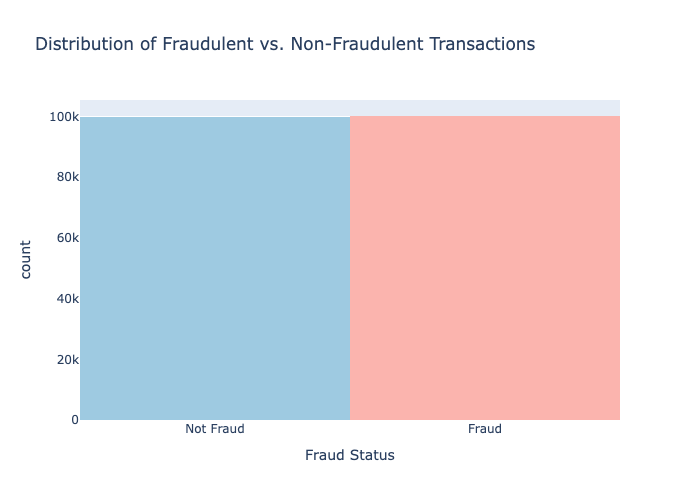

```
Plot 2: Fraud vs. Non-Fraud after sample and GANs
```

```python
import plotly.express as px

PASTEL_BLUE = "#9ecae1"
PASTEL_PINK = "#fbb4ae"

#--- Plot the class balance
fig = px.histogram(
    df, x="isFraud",
    color="isFraud",
    color_discrete_sequence=[PASTEL_BLUE, PASTEL_PINK],
    title="Distribution of Fraudulent vs. Non-Fraudulent Transactions",
    labels={"isFraud": "Fraud Status"},
    width=600, height=400
)
fig.update_xaxes(tickvals=[0,1], ticktext=["Not Fraud", "Fraud"])
fig.update_layout(showlegend=False)
# fig.show()
fig.write_image("p2.png")
display(Image(filename="p2.png"))
print("Plot 2: Fraud vs. Non-Fraud after sample and GANs")
```

## Visualizing Top 15 Features with Greatest Difference in Class (fraud vs non fraud)

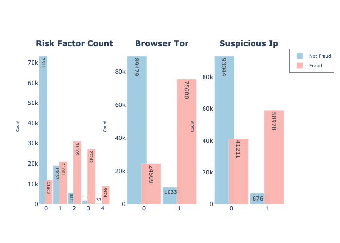

```
Plot 3: Fraud vs. All Categorical
```

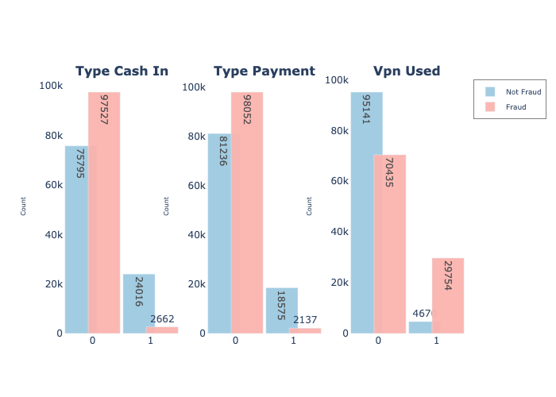

```
Plot 3: Fraud vs. All Categorical
```

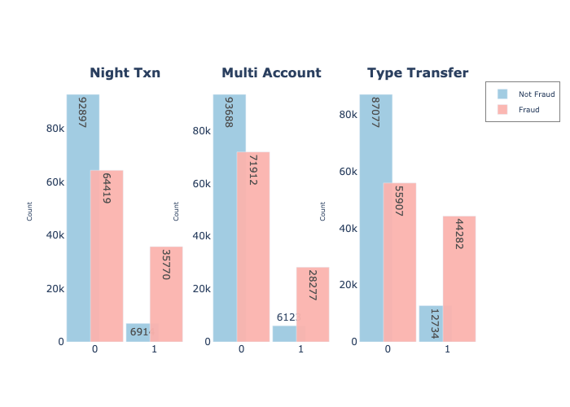

```
Plot 3: Fraud vs. All Categorical
```

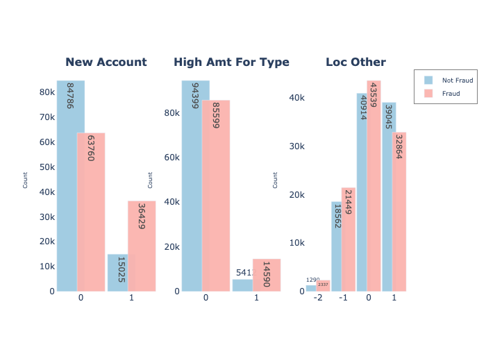

```
Plot 3: Fraud vs. All Categorical
```

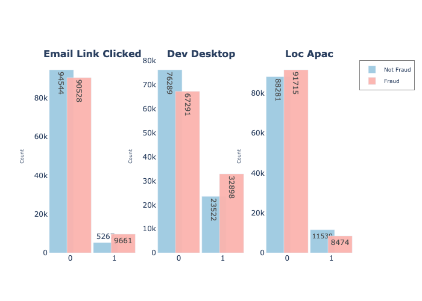

```
Plot 3: Fraud vs. All Categorical
```

```python
from plotly.subplots import make_subplots
import plotly.graph_objects as go


# Gets all categorical/binary columns with not more than 10 categories
cat_cols = [
    c for c in df.columns
    if df[c].nunique() <= 10 and c not in ["isFraud", "isFlaggedFraud"]
]

def top_class_difference_features(df, target, n=10):
    feature_scores = []
    for col in cat_cols:
        counts = df.groupby(col)[target].mean()
        score = abs(counts.max() - counts.min())
        feature_scores.append((col, score))
    return [x[0] for x in sorted(feature_scores, key=lambda x: -x[1])[:n]]

top15_fraud = top_class_difference_features(df, "isFraud", n=15)
top15_flagged = top_class_difference_features(df, "isFlaggedFraud", n=10)


def plot_categorical_counts_side_by_side(df, features, target, palette, batch_size=3):
    fraud_map = {0: "Not Fraud", 1: "Fraud"}
    n = len(features)
    for i in range(0, n, batch_size):
        batch = features[i:i+batch_size]
        cols = len(batch)
        fig = make_subplots(rows=1, cols=cols, subplot_titles=[
            f"<b>{col.replace('_', ' ').title()}</b>" for col in batch])
        for j, col in enumerate(batch, 1):
            value_counts = df.groupby([col, target]).size().reset_index(name="count")
            cats = sorted(df[col].unique())
            for idx, t in enumerate(sorted(df[target].unique())):
                vals = value_counts[value_counts[target]==t]
                # to only show legend for first sub plot
                show_leg = (j == 1)
                name = fraud_map.get(t, str(t)) if show_leg else Noney
                fig.add_trace(go.Bar(
                    x=vals[col].astype(str),
                    y=vals["count"],
                    name=name,
                    marker_color=palette[idx],
                    width=0.55,
                    text=vals["count"],
                    textposition='auto',
                    opacity=0.95,
                    showlegend=show_leg
                ), row=1, col=j)
            # Axis labels
            # fig.update_xaxes(title_text=col, title_font=dict(size=8), row=1, col=j)
            fig.update_yaxes(title_text="Count", title_font=dict(size=8), row=1, col=j)
        fig.update_layout(
            barmode="group",
            width=1100, height=400,
            legend=dict(
                orientation="v",
                font=dict(size=9),
                x=1.02, xanchor="left", y=1, yanchor="top",
                bgcolor="rgba(255,255,255,0.7)",
                bordercolor="gray",
                borderwidth=1
            ),
            plot_bgcolor="white",
            paper_bgcolor="white"
        )
        # fig.show()
        fig.write_image("p3.png")
        display(Image(filename="p3.png"))
        print("Plot 3: Fraud vs. All Categorical")

# Example usage:
plot_categorical_counts_side_by_side(df, top15_fraud, "isFraud", [PASTEL_BLUE, PASTEL_PINK])
```

Insights:

## Time-Based Feature Distributions by Fraud Status

- This code defines and uses a helper function to plot the distributions time based features created from the 'step' column we were provided, by the fraud label.

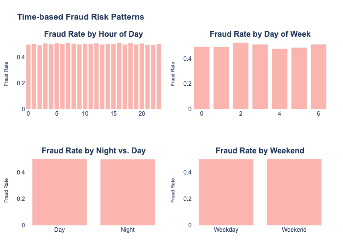

```
Plot 4: Fraud vs. Time based features
```

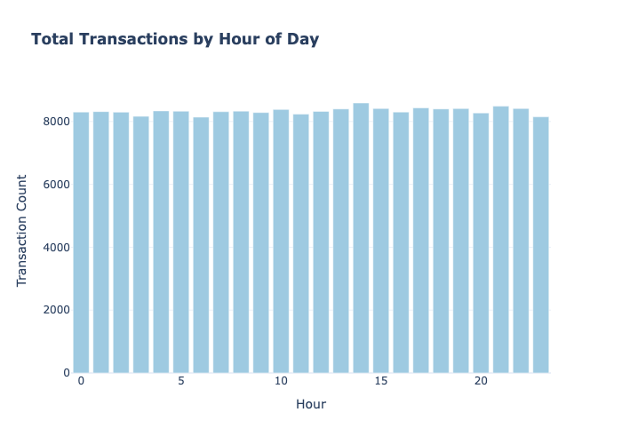

```
Plot 5: Fraud vs. Transaction count over hour of day
```

```python
from plotly.subplots import make_subplots
import plotly.graph_objects as go


# --- Deriving time-based features from 'step' coloumn
df['hour'] = df['step'] % 24
df['day_of_week'] = (df['step'] // 24) % 7
df['is_night'] = df['hour'].between(0, 6).astype(int)
df['is_weekend'] = df['day_of_week'].isin([5, 6]).astype(int)


# --- Prepare data for all four plots ---
fraud_by_hour = df.groupby('hour')['isFraud'].mean().reset_index()
fraud_by_day = df.groupby('day_of_week')['isFraud'].mean().reset_index()
fraud_by_night = df.groupby('is_night')['isFraud'].mean().reset_index()
fraud_by_weekend = df.groupby('is_weekend')['isFraud'].mean().reset_index()

# --- Subplot: Four time-based fraud rate charts, 2x2 grid ---
fig = make_subplots(
    rows=2, cols=2,
    subplot_titles=[
        "<b>Fraud Rate by Hour of Day</b>",
        "<b>Fraud Rate by Day of Week</b>",
        "<b>Fraud Rate by Night vs. Day</b>",
        "<b>Fraud Rate by Weekend</b>"
    ]
)

fig.add_trace(go.Bar(
    x=fraud_by_hour['hour'], y=fraud_by_hour['isFraud'],
    marker_color=PASTEL_PINK,
    showlegend=False
), row=1, col=1)

fig.add_trace(go.Bar(
    x=fraud_by_day['day_of_week'], y=fraud_by_day['isFraud'],
    marker_color=PASTEL_PINK,
    showlegend=False
), row=1, col=2)

fig.add_trace(go.Bar(
    x=['Day', 'Night'],
    y=fraud_by_night.sort_values('is_night')['isFraud'],
    marker_color=PASTEL_PINK,
    showlegend=False
), row=2, col=1)

fig.add_trace(go.Bar(
    x=['Weekday', 'Weekend'],
    y=fraud_by_weekend.sort_values('is_weekend')['isFraud'],
    marker_color=PASTEL_PINK,
    showlegend=False
), row=2, col=2)

fig.update_layout(
    height=700, width=1100,
    plot_bgcolor="white", paper_bgcolor="white",
    title_text="<b>Time-based Fraud Risk Patterns</b>",
    font=dict(size=12, family="Arial"),
    margin=dict(l=40, r=30, t=80, b=40)
)

for i in range(1, 3):
    fig.update_xaxes(title_font=dict(size=10), row=1, col=i)
    fig.update_xaxes(title_font=dict(size=10), row=2, col=i)
    fig.update_yaxes(title_text="Fraud Rate", title_font=dict(size=10), row=1, col=i)
    fig.update_yaxes(title_text="Fraud Rate", title_font=dict(size=10), row=2, col=i)

# fig.show()
fig.write_image("p4.png")
display(Image(filename="p4.png"))
print("Plot 4: Fraud vs. Time based features")

# --- Transaction count over hour of day (as before) ---
import plotly.express as px
txns_per_hour = df['hour'].value_counts().sort_index()
fig = px.bar(
    x=txns_per_hour.index, y=txns_per_hour.values,
    labels={'x': 'Hour', 'y': 'Transaction Count'},
    title="<b>Total Transactions by Hour of Day</b>",
    color_discrete_sequence=[PASTEL_BLUE], width=1100, height=400,
    template='plotly_white')

# fig.show()
fig.write_image("p5.png")
display(Image(filename="p5.png"))
print("Plot 5: Fraud vs. Transaction count over hour of day")
```

Insights:

- The overall transaction volume stays almost perfectly flat across all hours of the day. This suggests there’s no business-driven transaction surge at any specific time, so time-of-day alone doesn’t separate fraud from non-fraud.
- The fraud rate by hour is also extremely steady, with almost no difference between early morning, midday, or late night hours. Attackers may be distributing their activity to avoid time-based detection.
- There’s only minimal variation in fraud rate across days of the week. No specific weekday or weekend effect is visible in this data; fraud risk remains consistent from Monday to Sunday.
- The fraud rate doesn't change meaningfully between night and day transactions. Nighttime does not pose extra risk in this synthetic data.
- There is also no significant difference in fraud risk between weekends and weekdays so these may not be the best predictors for our model.

## Fraud Counts by Transaction Type

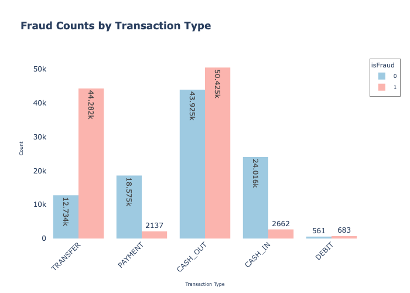

```
Plot 6: Fraud Counts by Transaction Type
```

```python
# Recreating the 'type' categorical coloumn since we one-hot encoded it earlier but dropped the original coloumn.
# We could just include that column but this is good to know how to do this.

type_cols = [c for c in df.columns if c.startswith('type_')]

def recover_type(row):
    for col in type_cols:
        if row[col] == 1:
            return col.replace('type_', '')
    return "OTHER"

if 'type' not in df.columns:
    df['type'] = df[type_cols].apply(recover_type, axis=1)

import plotly.express as px

fig = px.histogram(
    df, x='type', color='isFraud',
    barmode="group", text_auto=True,
    title="<b>Fraud Counts by Transaction Type</b>",
    color_discrete_sequence=[PASTEL_BLUE, PASTEL_PINK]
)
fig.update_layout(
    width=800, height=450,
    xaxis_tickangle=-45,
    xaxis_title=dict(text="Transaction Type", font=dict(size=8)),
    yaxis_title=dict(text="Count", font=dict(size=8)),
    legend=dict(
        orientation="v",
        font=dict(size=9),
        x=1.02, xanchor="left", y=1, yanchor="top",
        bgcolor="rgba(255,255,255,0.7)",
        bordercolor="gray",
        borderwidth=1
    ),
    plot_bgcolor="white",
    paper_bgcolor="white"
)
# fig.show()
fig.write_image("p6.png")
display(Image(filename="p6.png"))
print("Plot 6: Fraud Counts by Transaction Type")
```

Insights:

- Fraud is heavily concentrated in CASH_OUT and TRANSFER transactions. These types account for the vast majority of fraud cases in the data.
- Legitimate transactions make up the bulk of PAYMENT and CASH_IN activity, with very few fraud cases in these categories.
- Both fraud and non-fraud counts are low for DEBIT, indicating this type is rare overall.
- Transaction type clearly separates risky from safe activity, making it a key feature for any fraud model.

## Exploring Risk Flags, Device, and Geo Patterns

- This section focuses on risk signals such as VPN use, Tor browser, suspicious IP, device type, and manual review triggers.
- Visualizes fraud rates for each flag, highlighting which features actually separate fraud from normal activity.

[figure not shown]

```
Plot 7: Fraud Counts by Fraud Rate by Device and Location and Other Similar Features
```

```python
import plotly.express as px
from plotly.subplots import make_subplots
import plotly.graph_objects as go

risk_flag_cols = [
    'dev_mobile', 'dev_desktop', 'isp_known', 'vpn_used',
    'flag_manual_review', 'two_factor_used', 'suspicious_ip', 'browser_tor',
    'suspicious_zero_dest_after', 'risk_factor_count'
]

custom_pinks = [
    "#ffb6c1", "#fbb4ae", "#fdcce5", "#f8bbd0", "#e7b6c9",
    "#ffcccb", "#ffdde4", "#f8a5c2", "#f6abb6", "#ffafcc"
]

fraud_rates = []
for col in risk_flag_cols:
    temp = df.groupby(col, as_index=False)["isFraud"].mean()
    temp['feature'] = col
    fraud_rates.append(temp)
fraud_rates_df = pd.concat(fraud_rates, ignore_index=True)

fig = make_subplots(
    rows=2, cols=5,
    subplot_titles=[col.replace('_', ' ').title() for col in risk_flag_cols]
)

annotations = []

for i, col in enumerate(risk_flag_cols):
    r, c = divmod(i, 5)
    data = fraud_rates_df[fraud_rates_df['feature'] == col]
    x_labels = data[col].astype(str)
    y_vals = data["isFraud"]
    bar_color = custom_pinks[i % len(custom_pinks)]
    fig.add_trace(
        go.Bar(
            x=x_labels,
            y=y_vals,
            marker_color=bar_color,
            showlegend=False
        ),
        row=r+1, col=c+1
    )
    # Add annotation for each bar (inside top of bar)
    for xi, yi in zip(x_labels, y_vals):
        # Offset is a small fraction of the bar height so text is inside
        offset = 0.02 if yi > 0.1 else yi * 0.2
        annotations.append(dict(
            x=xi, y=yi - offset,
            text=f"{int(round(yi*100))}%",
            showarrow=False,
            font=dict(size=12, color="black"),
            xanchor="center",
            yanchor="top",
            xref=f"x{i+1}",
            yref=f"y{i+1}"
        ))

fig.update_layout(
    height=2200,    # Not too tall
    width=800,     # Much wider!
    plot_bgcolor="white", paper_bgcolor="white",
    title_text="<b>Fraud Rate by Device and Location</b>",
    font=dict(size=14, family="Arial"),
    margin=dict(l=40, r=30, t=80, b=40),
    annotations=annotations
)

# Reduce subplot title font size
for anno in fig['layout']['annotations']:
    if 'text' in anno and 'Fraud Rate by' not in anno['text']:  # Only subplot titles
        anno['font'] = dict(size=14)
    elif 'text' in anno:  # This is one of your bar annotations
        anno['font'] = dict(size=13, color="black")


for i in range(1, 6):
    fig.update_xaxes(title_font=dict(size=8), row=1, col=i)
    fig.update_xaxes(title_font=dict(size=8), row=2, col=i)
    fig.update_yaxes(title_text="Fraud Rate", title_font=dict(size=8), row=1, col=i)
    fig.update_yaxes(title_text="Fraud Rate", title_font=dict(size=8), row=2, col=i)

# fig.show()
fig.write_image("p7.png")
display(Image(filename="p7.png"))
print("Plot 7: Fraud Counts by Fraud Rate by Device and Location and Other Similar Features")
```

Insights:

## Investigating Correlations Among Features

- This correlation heatmap compares the relationships between the top 25 categorical and binary features and the fraud target using Cramér’s V, a correlation measure which is suited for categorical vars.
- Cramér’s V is used here because it handles binary and multi-class features, and finds non-linear associations that might be missed by linear methods.
- The upper triangle heatmap displays all pairwise correlations, with red boxes marking feature pairs that are significantly related.

[figure not shown]

```
Plot 8: Cramer's V Correlation Heatmap
```

```python
import scipy.stats as ss

def cramers_v(x, y):
    confusion_matrix = pd.crosstab(x, y)
    chi2 = ss.chi2_contingency(confusion_matrix)[0]
    n = confusion_matrix.sum().sum()
    phi2 = chi2 / n
    r, k = confusion_matrix.shape
    phi2corr = max(0, phi2 - ((k-1)*(r-1))/(n-1))
    rcorr = r - ((r-1)**2)/(n-1)
    kcorr = k - ((k-1)**2)/(n-1)
    return np.sqrt(phi2corr / min((kcorr-1), (rcorr-1)))


# Get top 25 categorical/binary features by class separation
cat_cols = [c for c in df.columns if df[c].nunique() <= 10 and c not in ["isFraud", "isFlaggedFraud"]]
top25_cat = top_class_difference_features(df, "isFraud", n=25)

def cramers_v_matrix(df, cols):
    n = len(cols)
    mat = np.full((n, n), np.nan)  # Default all to blank/white
    for i, a in enumerate(cols):
        for j, b in enumerate(cols):
            if i <= j:   # Upper triangle (including diagonal)
                mat[i, j] = cramers_v(df[a], df[b])
    return mat

top25_cat_cols = top25_cat
mat = cramers_v_matrix(df, top25_cat_cols + ["isFraud"])

labels = [c.replace("_", "\n") for c in top25_cat_cols + ["isFraud"]]
thresh = 0.15

# Prepare annotation text matrix: blank for lower triangle, 1 decimal elsewhere
text_matrix = np.empty(mat.shape, dtype=object)
for i in range(mat.shape[0]):
    for j in range(mat.shape[1]):
        if i <= j and not np.isnan(mat[i, j]):
            text_matrix[i, j] = f"{mat[i, j]:.1f}"
        else:
            text_matrix[i, j] = ""

# Find coordinates for significant cells (not diagonal)
xs, ys = [], []
for i in range(mat.shape[0]):
    for j in range(mat.shape[1]):
        val = mat[i, j]
        if i < j and not np.isnan(val) and val >= thresh and val != 1:
            xs.append(labels[j])
            ys.append(labels[i])

import plotly.graph_objects as go

fig = go.Figure()

# Main heatmap
fig.add_trace(go.Heatmap(
    z=mat,
    x=labels,
    y=labels,
    colorscale=[[0, PASTEL_PINK], [1, PASTEL_BLUE]],
    colorbar=dict(title="Cramer's V"),
    zmin=0, zmax=1,
    hoverongaps=False,
    text=text_matrix,
    texttemplate="%{text}"
))

# Overlay scatter for red box markers (not on diagonal)
fig.add_trace(go.Scatter(
    x=xs,
    y=ys,
    mode="markers",
    marker=dict(
        symbol="square-open",
        color="red",
        size=10,
        line=dict(width=0.5)
    ),
    hoverinfo="skip",
    showlegend=False
))

fig.update_layout(
    title=f"Cramer's V Matrix (Upper Triangle, Red Box = V ≥ {thresh}) — Top 25 Categorical Fraud Features + isFraud",
    width=800,
    height=1200,
    font=dict(size=10, family="Arial"),
    margin=dict(l=150, r=60, b=180, t=100, pad=4)
)

fig.update_xaxes(tickangle=45, side="bottom", automargin=True)
fig.update_yaxes(automargin=True)

fig.write_image("p8.png", scale=2)
display(Image(filename="p8.png"))
print("Plot 8: Cramer's V Correlation Heatmap")
```

Insights:

- Risk factor count has strong overlap with key risk flags like browser_tor and suspicious_ip, which makes sense since it aggregates these indicators.
- Several fraud flags, including suspicious_ip, browser_tor, vpn_used, and type_TRANSFER, often appear together in the same transactions.
- Transaction type and device features show much weaker correlation, meaning they add fresh signals that aren’t just repeats of other risk flags.
- No signs of direct leakage but the stacked risk feature, 'risk factor count' is highly related and could be a cuase of collinearity in the model.